# Molecular Marker Assisted Plant Breeding

Bayesian Alphabet

Felipe Ferrão

University of Florida

**Objectives:**

- 60 minutes of hands-on
- Introduction to BGLR and the Bayesian Alphabet
- Running simple simulations in R

**Extra information**

- [HOS 6236 – Website](https://lfelipe-ferrao.github.io/class/mas/)
- About the [author](https://lfelipe-ferrao.github.io/)
- About the [UF/IFAS Plant Breeding](https://programs.ifas.ufl.edu/plant-breeding/)

# Introduction

The Bayesian Alphabet refers to a family of Bayesian regression models developed for genomic selection (GS) — the prediction of genetic merit or breeding values using genome-wide markers. These models share a common Bayesian framework but differ in their assumptions about the distribution of marker effects.

In genomic selection, thousands of single nucleotide polymorphisms (SNPs) are used to predict complex traits. Traditional methods struggle with this “large p, small n” problem (many predictors, few observations), so Bayesian models are particularly useful because they can regularize estimates and incorporate prior information.

# Bayesian Alphabet Models

**Model Specification in a Matrix Notation**

$$\mathbf{y} = \mathbf{X}\boldsymbol{\beta} + \mathbf{Z}\mathbf{u} +
\boldsymbol{\varepsilon}$$

where:

- $\mathbf{y}$: vector of phenotypic observations ($n \times 1$)
- $\mathbf{X}$: design matrix for fixed effects ($n \times p$)
- $\boldsymbol{\beta}$: vector of fixed effects ($p \times 1$)
- $\mathbf{Z}$: matrix of genotypes (e.g., marker matrix, $n \times m$)
- $\mathbf{u}$: vector of marker effects ($m \times 1$)
- $\boldsymbol{\varepsilon}$: residual vector ($n \times 1$)

**Likelihood**

$$\mathbf{y} \mid \boldsymbol{\beta}, \mathbf{u}, \sigma^2_\varepsilon
\sim \mathcal{N}(\mathbf{X}\boldsymbol{\beta} + \mathbf{Z}\mathbf{u}, \,
\sigma^2_\varepsilon \mathbf{I}_n)$$

Hence, the likelihood is:

$$p(\mathbf{y} \mid \boldsymbol{\beta}, \mathbf{u}, \sigma^2_\varepsilon)
=
(2\pi\sigma^2_\varepsilon)^{-\frac{n}{2}}
\exp\left[
-\frac{1}{2\sigma^2_\varepsilon}
(\mathbf{y} - \mathbf{X}\boldsymbol{\beta} - \mathbf{Z}\mathbf{u})'
(\mathbf{y} - \mathbf{X}\boldsymbol{\beta} - \mathbf{Z}\mathbf{u})
\right]$$

**Priors**

$$\begin{aligned}
\boldsymbol{\beta} &\sim \mathcal{N}(\mathbf{0}, \, \sigma^2_\beta
\mathbf{I}_p) \\
\mathbf{u} &\sim \mathcal{N}(\mathbf{0}, \, \sigma^2_u \mathbf{I}_m)
\\
\sigma^2_u &\sim \text{Scaled-Inv-}\chi^2(\nu_u, S_u) \\
\sigma^2_\varepsilon &\sim \text{Scaled-Inv-}\chi^2(\nu_\varepsilon,
S_\varepsilon)
\end{aligned}$$

**Posterior Distribution**

$$p(\boldsymbol{\beta}, \mathbf{u}, \sigma^2_\varepsilon, \sigma^2_u \mid
\mathbf{y})
\propto
p(\mathbf{y} \mid \boldsymbol{\beta}, \mathbf{u}, \sigma^2_\varepsilon)
\, p(\boldsymbol{\beta}) \,
p(\mathbf{u} \mid \sigma^2_u)
\, p(\sigma^2_u)
\, p(\sigma^2_\varepsilon)$$

Expanded form:

$$\begin{aligned}
p(\boldsymbol{\beta}, \mathbf{u}, \sigma^2_\varepsilon, \sigma^2_u \mid
\mathbf{y})
&\propto
(\sigma^2_\varepsilon)^{-\frac{n}{2}}
\exp\left[-\frac{1}{2\sigma^2_\varepsilon}
(\mathbf{y}-\mathbf{X}\boldsymbol{\beta}-\mathbf{Z}\mathbf{u})'
(\mathbf{y}-\mathbf{X}\boldsymbol{\beta}-\mathbf{Z}\mathbf{u})
\right] \\
&\quad \times
(\sigma^2_u)^{-\frac{m}{2}}
\exp\left[-\frac{1}{2\sigma^2_u}\mathbf{u}'\mathbf{u}\right]
\times
p(\boldsymbol{\beta})
\, p(\sigma^2_u)
\, p(\sigma^2_\varepsilon)
\end{aligned}$$

**Inference**

Posterior inference is typically done using **Gibbs sampling**, where conditional posteriors are derived as:

$$\begin{aligned}
\boldsymbol{\beta} \mid \mathbf{u}, \sigma^2_\varepsilon, \mathbf{y}
&\sim \mathcal{N}(\cdot, \cdot) \\
\mathbf{u} \mid \boldsymbol{\beta}, \sigma^2_u, \sigma^2_\varepsilon,
\mathbf{y} &\sim \mathcal{N}(\cdot, \cdot) \\
\sigma^2_u \mid \mathbf{u} &\sim \text{Scaled-Inv-}\chi^2(\cdot,
\cdot) \\
\sigma^2_\varepsilon \mid \mathbf{y}, \mathbf{u}, \boldsymbol{\beta}
&\sim \text{Scaled-Inv-}\chi^2(\cdot, \cdot)
\end{aligned}$$

**Statistical and Biological assumptions**

Below, we present the **Bayesian Whole-Genome Regression** model using a **hierarchical structure**. The intuition behind this framework is straightforward: each component of the model is treated as a **random variable** that follows a probability distribution. This idea lies at the heart of the Bayesian paradigm — uncertainty in all unknown quantities (parameters, effects, and variances) is modeled through probability distributions. In the genomic context, the key difference from classical approaches lies in how **marker effects** are treated. While they are all assumed to follow a normal distribution statistically, the **variance structure** associated with each effect introduces biological meaning. By modifying assumptions on the variance components, we can represent different genetic architectures — for instance, whether all markers have small effects (polygenic traits) or whether only a few have large effects (oligogenic or sparse traits). More details in the sequence:

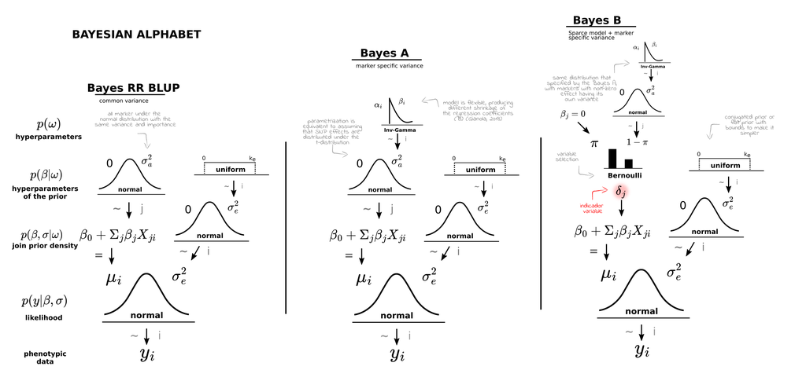

Probabilistic formulation of the Bayesian Regression Models commonly used in genomic prediction. This is called the Bayesian Alphabet in the specialized literature, indicating different assumptions about the marker effects and therefore on the genetic architecture of the trait

## Prios for the marker effects

### BayesRR (Bayesian Ridge Regression)

**Prior for marker effects:**

$\beta_j \sim N(0, \sigma_\beta^2)$

**Assumptions:**

- All markers contribute to the trait.
- Marker effects are normally distributed with a common variance.
- No sparsity — every marker has a small effect.
- Equivalent to ridge regression BLUP (RR-BLUP) in the frequentist setting.

### BayesA

**Prior for marker effects:**

$\beta_j \sim N(0, \sigma_j^2), \quad \sigma_j^2 \sim \text{Scaled-Inv-}\chi^2(\nu_\beta, S_\beta^2)$

**Assumptions:**

- All markers have an effect.
- Each marker has its own variance $\sigma_j^2$ drawn from an inverse chi-squared prior.
- Produces a heavy-tailed prior, allowing a few markers to have large effects.
- Continuous shrinkage model (no exact zeros).

### BayesB

**Prior for marker effects:**

$$\beta_j \sim
\begin{cases}
0, & \text{with probability } \pi \\
N(0, \sigma_j^2), & \text{with probability } 1 - \pi
\end{cases},
\quad
\sigma_j^2 \sim \text{Scaled-Inv-}\chi^2$$

**Assumptions:**

- Many markers have no effect (set to zero).
- A small proportion have normally distributed effects with their own variances.
- Incorporates variable selection through $\pi$.
- Suitable for traits controlled by a few loci with large effects.

### BayesC

**Prior for marker effects:**

$$\beta_j \sim
\begin{cases}
0, & \text{with probability } \pi \\
N(0, \sigma_\beta^2), & \text{with probability } 1 - \pi
\end{cases}$$

**Assumptions:**

- Similar to BayesB, but all non-zero effects share a common variance $\sigma_\beta^2$.
- Simpler and more computationally stable.
- The proportion of zero effects ($\pi$) is fixed.

### BayesCπ

**Prior for marker effects:**

$$\beta_j \sim
\begin{cases}
0, & \text{with probability } \pi \\
N(0, \sigma_\beta^2), & \text{with probability } 1 - \pi
\end{cases}$$

**Assumptions:**

- Same as BayesC, but the proportion of zero effects ($\pi$) is estimated from the data.
- Allows the model to adapt between sparse and polygenic genetic architectures.

### BayesLASSO

**Prior for marker effects:**

$p(\beta_j|\lambda) = \dfrac{\lambda}{2} e^{-\lambda|\beta_j|}$

or equivalently,

$\beta_j | \tau_j^2 \sim N(0, \tau_j^2 \sigma_\varepsilon^2), \quad \tau_j^2 \sim \text{Exp}\left(\dfrac{\lambda^2}{2}\right)$

**Assumptions:**

- All markers have effects, but these are continuously shrunk toward zero.
- Uses a Laplace (double-exponential) prior to penalize large effects.
- Produces many small effects, with some larger ones retained.
- No explicit variable selection (no hard zeros).

### Summary of Bayesian Alphabet Models

| Model | Prior for $\beta_j$ | Effect Assumptions |
| --- | --- | --- |
| **BayesRR** | $N(0, \sigma_\beta^2)$ | All markers contribute; common variance; no sparsity |
| **BayesA** | $N(0, \sigma_j^2),\ \sigma_j^2 \sim \text{Scaled-Inv-}\chi^2$ | All markers contribute; marker-specific variance; heavy-tailed |
| **BayesB** | $0$ w.p. $\pi$, $N(0, \sigma_j^2)$ w.p. $1-\pi$ | Most markers zero; few markers have individual variances |
| **BayesC** | $0$ w.p. $\pi$, $N(0, \sigma_\beta^2)$ w.p. $1-\pi$ | Sparse effects; common variance for non-zero markers |
| **BayesCπ** | Same as BayesC, $\pi$ estimated from data | Sparse effects; estimated proportion of zeros |
| **BayesLASSO** | $p(\beta_j\|\lambda)=\frac{\lambda}{2} e^{-\lambda\|\beta_j\|}$ | All markers contribute; continuously shrunk toward zero |

# Hands on

## Coffee: Bayesian Alphabet

- [Ferrão et al., 2023](https://acsess.onlinelibrary.wiley.com/doi/full/10.1002/tpg2.20321)
- Genotyping-by-sequencing: 58k markers
- Population size: 222 genotypes
- Randomized complete block design with three replications
- Four consecutive harvest-production years (2008–2011)

### Reading the data

```r
# Load required libraries
library(openxlsx)
library(dplyr)
library(lme4)
library(emmeans)
library(purrr)
library(GWASpoly)

# Genomic information
load("/home/felipe/Dropbox (UFL)/classes/Molecular_Breeding/class5_GWAS/GWASmodels/coffee_example_222ind_58k.Rdata")

# Load phenotype data
pheno <- read.xlsx("/home/felipe/Dropbox (UFL)/classes/Molecular_Breeding/class5_GWAS/GWASmodels/coffee_phenotype.xlsx")

# Create unique ID and filter for IDs present in M
pheno <- pheno %>%
  mutate(id = paste(pop, trat, sep = "_"),
         yield =`BeanWeight(g)`/5 ) %>% # put in the original scale, kg per plant
  filter(id %in% colnames(M))
```

### Phenotypic Data

- Trait 1: yield data, in Kg per plant
- Trait 2: ratio between the raw harvested fruit (coffee cherries) and the processed, dried, hulled beans — ready for roasting (green coffee). The ratio indicates how much of the harvested fruit ends up as usable coffee.
- Trait 3: bean residual (RES). In coffee grading, beans are passed through a series of sieves with different hole sizes. Larger beans remain on top of larger sieves (e.g., sieve 18). Smaller beans fall through to lower sieves or the bottom (residual). The fraction of beans retained at the bottom, i.e., beans too small to be retained by any standard sieve size. A high sieve residual implies a higher proportion of small or defective beans, which are considered lower quality.

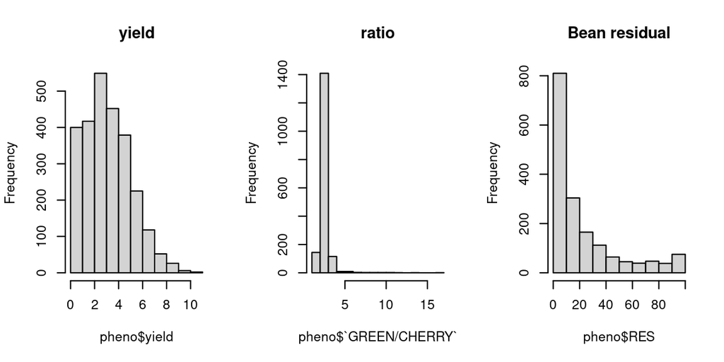

```r
par(mfrow=c(1,3))
hist(pheno$yield, main="yield")
hist(pheno$`GREEN/CHERRY`, main="ratio")
hist(pheno$RES, main="Bean residual")
```

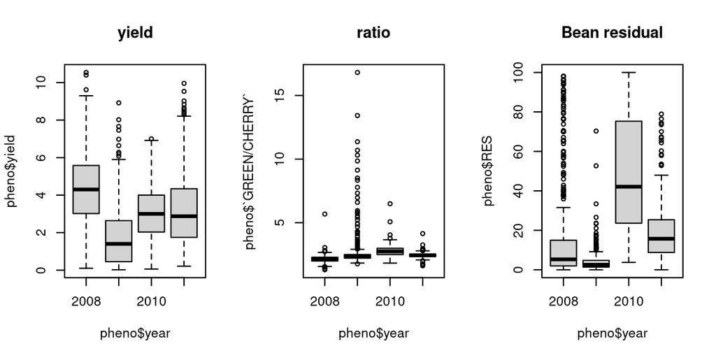

```r
# Factorize categorical variables
pheno <- pheno %>%  mutate(across(c(id, block, year), as.factor))

# Distributiona cross the years

par(mfrow=c(1,3))
boxplot(pheno$yield~pheno$year, main="yield")
boxplot(pheno$`GREEN/CHERRY`~pheno$year, main="ratio")
boxplot(pheno$RES~pheno$year, main="Bean residual")
```

**Phenotypic Model**

$$y_{ijk} = \mu + \text{block}_i + geno_j
+ year_k + (geno\times year)_{jk} + \varepsilon_{ijk}$$

### Whole-genomic prediction

For the example we will use the so-called two stage analysis. By two-stages, we mean that we will extract the adjusted means from the first phenotypic analysis and use it as our response variable (output values) in the genomic prediction models. As a simple metric for the first stage, we will consider the mean phenotypic values, per genotype, across the years and block – this is a good proxy of the empirical BLUEs associated for this experimental design. In another class, we will address the questions/concerns on using single or two stage analysis.

- Phenotypic values: average values across the traits
- Models: BayesA, BayesB, BayesC and BayesRR

```r
library(AGHmatrix)
library(BGLR)
library(dplyr
        )
## Download the genomic data
load("/home/felipe/Dropbox (UFL)/classes/Molecular_Breeding/class5_GWAS/GWASmodels/coffee_example_222ind_58k.Rdata")
# Assuming you have a genomic relationship matrix G

# Filtering the markers
M1 = M[,-c(1:3)]; X = Mcheck(t(M1+1))

## Phenotypic data
pheno = read.xlsx("/home/felipe/Dropbox (UFL)/classes/Molecular_Breeding/class5_GWAS/GWASmodels/coffee_phenotype.xlsx")

df_sorted <- pheno %>%
  mutate(id = paste(pop, trat, sep = "_"),
         yield =`BeanWeight(g)`/5 ) %>% # put in the original scale, kg per plant
  filter(id %in% colnames(M))

# Create a new data frame with mean values per id for each trait
df_means <- df_sorted %>%
  group_by(id) %>%
  summarise(
    yield = mean(yield, na.rm = TRUE),
    GREEN_CHERRY = mean(GREEN/CHERRY, na.rm = TRUE),
    RES = mean(RES, na.rm = TRUE)
  )

# Selected traits and models
traits <- c("yield", "GREEN_CHERRY", "RES")  # adjust the exact column names
models <- list(
  BayesA  = list(model = "BayesA"), BayesB  = list(model = "BayesB"),
  BayesC  = list(model = "BayesC"), BayesRR = list(model = "BRR")
)

## BGLR and the  Bayesian Alphabet
setwd("/home/felipe/Dropbox (UFL)/classes/Molecular_Breeding/class6_GS/BayesianAlphabet/outputs_BGLR")
results <- list()  # to store results

# Fiting the models
for(tr in traits){
  y <- df_means[[tr]]
  names(y) <- df_means$id
  for(mod_name in names(models)){
    cat("Trait:", tr, "Model:", mod_name, "\n")
    ETA <- list(list(X = X, model = models[[mod_name]]$model))
    fm <- BGLR(y      = y,
               ETA    = ETA,
               nIter  = 5000,
               burnIn = 100,
               verbose = F,
               saveAt = paste0("BGLR_", tr, "_", mod_name, "_"))
    results[[tr]][[mod_name]] <- fm # Save results
  }
  }

# Saving the results in a list
save(results, file = "/home/felipe/Dropbox (UFL)/classes/Molecular_Breeding/class6_GS/BayesianAlphabet/outputs_BGLR/BGLR_results.Rdata")
```

**Yield results**

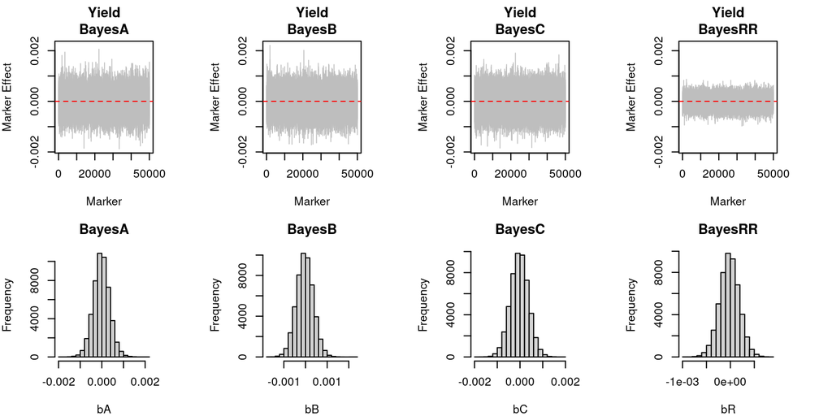

```r
load("/home/felipe/Dropbox (UFL)/classes/Molecular_Breeding/class6_GS/BayesianAlphabet/outputs_BGLR/BGLR_results.Rdata")
# Extract betas
bA <- results$yield$BayesA$ETA[[1]]$b
bB <- results$yield$BayesB$ETA[[1]]$b
bC <- results$yield$BayesC$ETA[[1]]$b
bR <- results$yield$BayesRR$ETA[[1]]$b

# Set common y-axis limits
ylim_range <- range(c(bA, bB, bC, bR), na.rm = TRUE)

# Plot layout
par(mfrow = c(2, 4), mar = c(4, 4, 3, 4))  # extra right margin for histogram

# Custom plotting function
plot_beta <- function(b, main_title) {
  plot(b, type = "h", lwd = 0.8,
       col = "gray", main = main_title,
       ylab = "Marker Effect", xlab = "Marker",
       ylim = ylim_range)
  abline(h = 0, col = "red", lty = 2)}


# Plot each model
plot_beta(bA, "Yield\nBayesA")
plot_beta(bB, "Yield\nBayesB")
plot_beta(bC, "Yield\nBayesC")
plot_beta(bR, "Yield\nBayesRR")

# Add histogram on right
plot_hist <- function(b, main_title) {
  hist(b, axes = FALSE, xlab = "", ylab = "", main = "",
     col = rgb(1, 0, 0, 0.2), border = NA,
     breaks = 30, freq = TRUE,
     horiz = FALSE, ylim = ylim_range)
axis(side = 4)
mtext("Histogram", side = 4, line = 2)
}

hist(bA, main=  "BayesA")
hist(bB,main= "BayesB")
hist(bC, main= "BayesC")
hist(bR, main = "BayesRR")
```

**GREEN/CHERRY results**

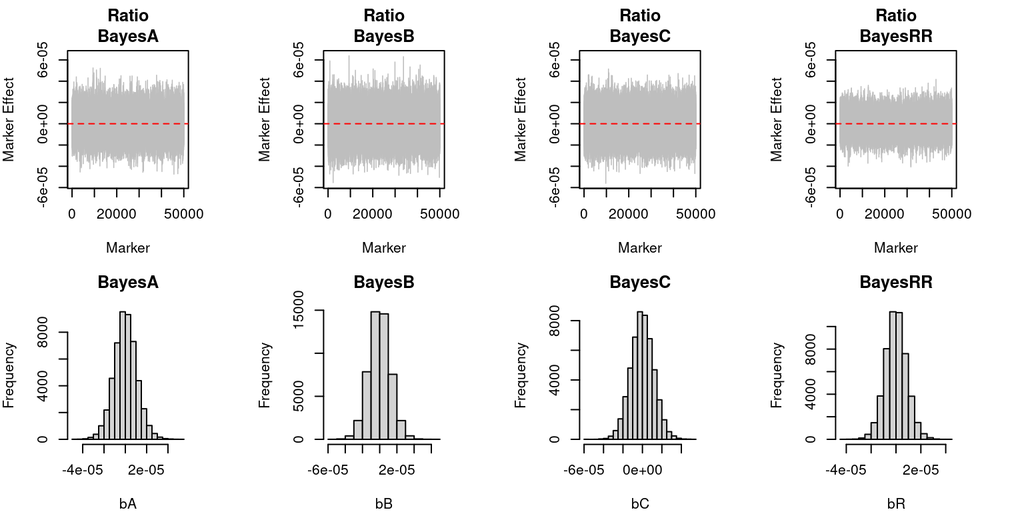

```r
load("/home/felipe/Dropbox (UFL)/classes/Molecular_Breeding/class6_GS/BayesianAlphabet/outputs_BGLR/BGLR_results.Rdata")
# Extract betas
bA <- results$GREEN_CHERRY$BayesA$ETA[[1]]$b
bB <- results$GREEN_CHERRY$BayesB$ETA[[1]]$b
bC <- results$GREEN_CHERRY$BayesC$ETA[[1]]$b
bR <- results$GREEN_CHERRY$BayesRR$ETA[[1]]$b

# Set common y-axis limits
ylim_range <- range(c(bA, bB, bC, bR), na.rm = TRUE)

# Plot layout
par(mfrow = c(2, 4), mar = c(4, 4, 3, 4))  # extra right margin for histogram

# Custom plotting function
plot_beta <- function(b, main_title) {
  plot(b, type = "h", lwd = 0.8,
       col = "gray", main = main_title,
       ylab = "Marker Effect", xlab = "Marker",
       ylim = ylim_range)
  abline(h = 0, col = "red", lty = 2)}


# Plot each model
plot_beta(bA, "Ratio\nBayesA")
plot_beta(bB, "Ratio\nBayesB")
plot_beta(bC, "Ratio\nBayesC")
plot_beta(bR, "Ratio\nBayesRR")

# Add histogram on right
plot_hist <- function(b, main_title) {
  hist(b, axes = FALSE, xlab = "", ylab = "", main = "",
     col = rgb(1, 0, 0, 0.2), border = NA,
     breaks = 30, freq = TRUE,
     horiz = FALSE, ylim = ylim_range)
axis(side = 4)
mtext("Histogram", side = 4, line = 2)
}

hist(bA, main=  "BayesA")
hist(bB,main= "BayesB")
hist(bC, main= "BayesC")
hist(bR, main = "BayesRR")
```

**Residual beans results**

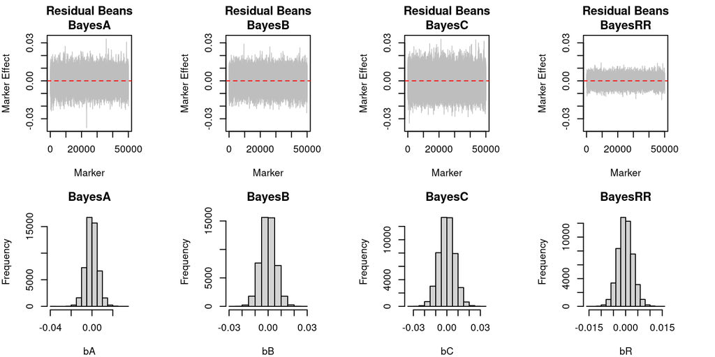

```r
load("/home/felipe/Dropbox (UFL)/classes/Molecular_Breeding/class6_GS/BayesianAlphabet/outputs_BGLR/BGLR_results.Rdata")
# Extract betas
bA <- results$RES$BayesA$ETA[[1]]$b
bB <- results$RES$BayesB$ETA[[1]]$b
bC <- results$RES$BayesC$ETA[[1]]$b
bR <- results$RES$BayesRR$ETA[[1]]$b

# Set common y-axis limits
ylim_range <- range(c(bA, bB, bC, bR), na.rm = TRUE)

# Plot layout
par(mfrow = c(2, 4), mar = c(4, 4, 3, 4))  # extra right margin for histogram

# Custom plotting function
plot_beta <- function(b, main_title) {
  plot(b, type = "h", lwd = 0.8,
       col = "gray", main = main_title,
       ylab = "Marker Effect", xlab = "Marker",
       ylim = ylim_range)
  abline(h = 0, col = "red", lty = 2)}


# Plot each model
plot_beta(bA, "Residual Beans\nBayesA")
plot_beta(bB, "Residual Beans\nBayesB")
plot_beta(bC, "Residual Beans\nBayesC")
plot_beta(bR, "Residual Beans\nBayesRR")

# Add histogram on right
plot_hist <- function(b, main_title) {
  hist(b, axes = FALSE, xlab = "", ylab = "", main = "",
     col = rgb(1, 0, 0, 0.2), border = NA,
     breaks = 30, freq = TRUE,
     horiz = FALSE, ylim = ylim_range)
axis(side = 4)
mtext("Histogram", side = 4, line = 2)
}

hist(bA, main=  "BayesA")
hist(bB,main= "BayesB")
hist(bC, main= "BayesC")
hist(bR, main = "BayesRR")
```

### Statistical diagnostics

The best alternative to check Bayesian diagnostic inference is looking the chain convergence and computing some metrics. Herein, we will use the the Gelman–Rubin diagnostic, also known as R (R-hat). It is a widely used method to check whether an MCMC chain (like those used in Bayesian models such as BGLR) has converged — meaning it is stable and representative of the target posterior distribution.

- It compares the variance within each MCMC chain to the variance between multiple chains.
- If chains have converged, both variances should be nearly equal, giving an R̂ close to 1.

| R̂ Value | Interpretation |
| --- | --- |
| **1.00 – 1.05** | Good convergence (ideal) |
| **1.05 – 1.10** | Acceptable but monitor |
| **> 1.10** | Poor convergence — more iterations or model adjustment needed |

**Example for the yield data**

```r
library(coda)
library(knitr)
library(dplyr)

trait <- "yield"
models <- c("BayesA", "BayesB", "BayesC", "BayesRR")
diagnostics <- data.frame()

for (model in models) {
  prefix <- paste0("BGLR_", trait, "_", model, "_")
  varE_path <- paste0(prefix, "varE.dat")

  if (!file.exists(varE_path)) {
    diagnostics <- rbind(diagnostics, data.frame(
      Model = model,
      Rhat = NA,
      ESS = NA
    ))
    next
  }

  varE <- scan(varE_path, quiet = TRUE)
  chain <- mcmc(cbind(varE = varE))

  # Gelman-Rubin using split-chain
  half <- floor(nrow(chain) / 2)
  mcmc_list <- mcmc.list(
    mcmc(chain[1:half, , drop = FALSE]),
    mcmc(chain[(half + 1):(2 * half), , drop = FALSE])
  )

  rhat <- gelman.diag(mcmc_list, autoburnin = FALSE)$psrf["varE", "Point est."]
  ess  <- effectiveSize(chain)["varE"]

  diagnostics <- rbind(diagnostics, data.frame(
    Model = model,
    Rhat = round(rhat, 3),
    ESS = round(ess, 1)
  ))
}

# Display the table
kable(diagnostics, caption = paste("Convergence Diagnostics for", trait))
```

Convergence Diagnostic for Yield

|  | Model | Rhat | ESS |
| --- | --- | --- | --- |
| varE | BayesA | 1.012 | 446.4 |
| varE1 | BayesB | 2.044 | 5.2 |
| varE2 | BayesC | 2.459 | 5.4 |
| varE3 | BayesRR | 1.001 | 91.0 |

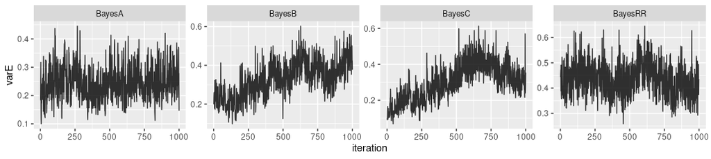

Trace plots for the residual variance computed using different models and the yield trait in a coffee example

```r
library(coda)
library(dplyr)
library(tidyr)
library(ggplot2)

trait <- "yield"
models <- c("BayesA", "BayesB", "BayesC", "BayesRR")
all_chains <- list()

for (model in models) {
  prefix <- paste0("BGLR_", trait, "_", model, "_")
  varE_path <- paste0(prefix, "varE.dat")

  if (!file.exists(varE_path)) {
    warning(paste("Missing:", varE_path))
    next
  }

  varE <- scan(varE_path, quiet = TRUE)
  df_chain <- data.frame(
    iteration = 1:length(varE),
    varE = varE,
    model = model
  )
  all_chains[[model]] <- df_chain
}

# Combine all into one data frame
chains_df1 <- bind_rows(all_chains)
ggplot(chains_df1, aes(x = iteration, y = varE)) +
  geom_line(color = "black", alpha = 0.8) +
  facet_wrap(~model, scales = "free_y", ncol = 4)
```

### Comments about the coffee results

- Check the distribution and the magnitude of the effects associated to the marker effects for each model.
- Do we need more iterations for the MCMC chain?
- Can we say something about the genetic architecture of the traits only looking for these results ?

# Final comments

The Bayesian Alphabet models — including BayesA, BayesB, BayesCπ, Bayesian Ridge Regression (BRR), and Bayesian LASSO — offer a flexible and powerful toolkit for genomic selection (GS). Each model represents different assumptions about the distribution and sparsity of marker effects, allowing breeders and geneticists to tailor analyses to the genetic architecture of the trait.

# References

- Ferrão MA, Da Fonseca AF, Volpi PS, de Souza LC, Comério M, Filho AC, Riva‐Souza EM, Munoz PR, Ferrão RG, Ferrão LF. Genomic‐assisted breeding for climate‐smart coffee. The Plant Genome. 2024 Mar;17(1):e20321.
- Kruschke, J. (2014). Doing Bayesian data analysis: A tutorial with R, JAGS, and Stan. [Link for the book](https://jkkweb.sitehost.iu.edu/index.html)
- Pérez, P., & de los Campos, G. (2014). Genome-wide regression and prediction with the BGLR statistical package. Genetics, 198(2), 483–495. https://doi.org/10.1534/genetics.114.164442